# Most Important Fisheries - Brazil

Daniel Viana

October 4, 2018

# 1. Introduction

Brazil has over 7 thousand kilometers of coastline and one of the largest river networks in the world, with only the Amazon River covering over 7 million kilometers square of water. Fisheries resources in Brazil are extremely important for income and food security of millions of people throughout the country. Despite enormous social and economic importance, many fish stock are over exploited and in risk of collapse. According to a study conducted by the Ministry of Environment, 80% of fish stocks are over exploited or fully exploited. This signals the urgency for sustainable management of fisheries in order to guarantee the livelihoods of fishers, improve food security in the country, and conserve marine biodiversity.

There is no basic fisheries statistics in the country since 2008. The lack of national fisheries statistics posed a great challenge to this study. Several researchers and fisheries managers consulted during the study pointed out the lack of data to provide basic information on Brazilian fisheries. Information such as how much the country produces, how much it consumes or even the number of fishers in the country is very sparse. In an interview with the most renowned fisheries scientist in the country, Dr. Fabio Hazin, he pointed out that there are between 400 thousand and one million fishers in the country. Additionally, he pointed out that data from FAO on Brazilian fisheries is mostly a copy of the production from the previous years. And this has been going on since 2008, when the last year of national fisheries statistics was recorded, and even then it wasn’t very reliable. Therefore, we had to be creative to conduct this study. We contacted people from all fisheries sectors to find out what was available. After an extensive search, we gathered six different databases representing the different fisheries sectors and conducted an extensive literature research. We also identified other potential sources of information that we were not able to obtain in time for this study.

The databases used were:

1. SIGSIF - Data obtained from the sanitary inspection services of the Brazilian Ministry of Agriculture. This database contains all seafood processed by fishing industries that caries a federal inspection certificate. This certificate is required for industries to commercialize their product to different states of Brazil and to export and import seafood products. It is a rigorous inspection program, where one of the requirements is to report all seafood that enters each company. Thus, this database includes all seafood products by species imported or from domestic production that enters all seafood processing companies with the federal inspection certificate (total of 472 companies). It includes both aquaculture and wild caught products from both freshwater and the oceanic species. 2016-2017.
2. CEAGESP - CEAGESP is the largest wholesale open seafood market in Latin America, located in the city of São Paulo. It is run by a state-owned company where sellers and buyers from all over the country gather to commercialize seafood and seafood products. We obtained information on all the seafood products commercialized in the market by species and price of commercialization. 2016-2017.
3. MDIC - Import and Export data from the Ministry of Development, Industry and Foreign Trade. This database contains all seafood imported and exported in Brazil. 2014-2017.
4. State fisheries landings - Fisheries landings data from three states of Brazil were there is continuous data collection and data are publicly available. These three states (São Paulo, Parana and Santa Catarina) are located in Southern Brazil and have a continuous data collection program sponsored by Petrobras in partnership with Universities. Petrobras is required to collect landings information for insurance purposes and has made some of its data publicly available for research projects. 2016-2017.
5. IBGE - Brazilian Institute of Geography and Statistics. This federal institute is responsible for surveying the country to provide basic information on all social aspects of Brazil. We gathered two pieces of information to inform our analysis: household food consumption and income by region of Brazil (last survey dates from 2009 and 2010).
6. Fishing Permits - Number of registered fishers in the country from the extinct Ministry of Fisheries and Aquaculture (MPA). 2003 - 2010.

# 2. Fisheries Context

# 3. Fisheries Employment and Income

## Top Fisheries by Employment

As pointed out in the introduction, Brazil has no reliable data on the number of fishers in the country. To respond this question we put together several pieces of information from different sources to have an estimate of the importance of fisheries for employment in Brazil.

Data from IBGE (2013) estimates that Brazil had about 500 thousand fishers throughout the country, with 90% from the small-scale sector and 10% from the industrial sector (Campos and Chaves 2016). Data from the extinct Ministry of Fisheries and Aquaculture (MPA) suggests there are many more fishers in Brazil (Figure 1). According to these data, there were about 900 thousand registered fishers in 2010 throughout the country, with 95% of the registered fishers from the small-scale sector (MPA, 2013). There is a large discrepancy between these two sources, which reiterates the uncertainty around estimates of the number of fishers in the country. Nonetheless, these numbers highlight the huge importance of the fisheries sector to employment in Brazil.

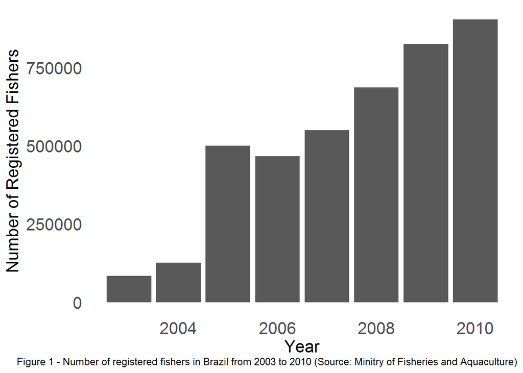

```r
###Number of registered fishers
rgp.data = read.csv("rgp_MPA.csv")

ggplot(rgp.data, aes(x = year, y = fishers)) +
  geom_bar(stat = "identity") +
  labs(x="Year", y="Number of Registered Fishers", caption = "Figure 1 - Number of registered fishers in Brazil from 2003 to 2010 (Source: Minitry of Fisheries and Aquaculture)") +
  ggtheme_plot()
```

Employment along the supply chain varies according to the region, fisheries and species commercialized. In the artisanal sector, most of the catch is consumed regionally, or in nearby capitals. However, some valuable fish and seafood are also commercialized in the main capitals - São Paulo and Rio de Janeiro. Typically, there are three main supply chain configurations in artisanal fisheries. First, there are estuarine/mangrove species (mostly crabs, shrimp and bivalves) that are commercialized whole in local markets or processed to achieve larger markets. For example, processing of crab meat is an important activity for coastal communities, especially for fisher woman. To obtain one kilogram of crab meat, a full day’s work is required, which involves extraction of the crab, cooking and manually removing the meat. This meat is then distributed through middleman to nearby cities and capitals. Second, most of the fish captured by the artisanal sector is consumed locally or regionally. In most cases, there is no record of the catch or commercialization of these fish, being sold in local markets and restaurants. Third, more valuable fish such as snappers, groupers, snook, weakfish and large shrimp are sold in capitals throughout the country. These fish are sold through middleman and larger seafood industries to large capitals, thus involving a larger number of people in the supply chain. Again, there is no reliable estimate on the total number of people employed in the supply chain of artisanal fisheries. The MPA estimates that there are about two million people involved in these fisheries (MPA, 2013).

Assuming that the number of fishers are between 500 thousand and 1 million, and that about 90% of them are from the small-scale sector, the most important fisheries for employment in the country are those from the artisanal sector. The artisanal sector is where we have the least amount of data on the production and species harvested. There is an estimate from the MPA that 50-70% of the catch from the entire country comes from the artisanal sector (MPA, 2013). Small-scale fisheries in Brazil target hundreds of species and there is no reliable information on the most important species for this sector.

Most of the registered fishers in Brazil are from the North and Northeast regions (MPA report, 2013). In these regions, freshwater resources from the Amazon and estuarine fisheries are very important. From the Amazonas state, the top commercialized fish are: curimatã (Prochilodus nigricans), jaraqui (Semaprochilodus spp.), matrinchã (Brycon amazonicus), pacu (Mylossoma duriventre), tambaqui (Colossoma macropomum) and tucunaré (Cichla monoculus) (data from the secretary of fisheries in the Amazon state - Sepror, 2018). In estuaries, there are many important resources such as the mangrove crabs, shrimps, bivalves, weakfish and snook (information gathered though literature review and interviews). Besides these fisheries, the small-scale fishers target all ecosystems and resources, such as pelagic, reefs, demersal and coastal. In the Northeast region for example, reef fisheries are very important, capturing some highly valued species such as snappers, groupers and lobsters. In the south, the mullet fishery is very important, with the first quota system for Brazil implemented in 2018 to manage this fishery. Therefore, the artisanal sector is a multi-species fishery, with the main species depending on the region and ecosystem.

```r
#State of Santa Catarina
sc.data = read.csv("Santa Catarina.csv")

###Graph main species - production
sc.prod = sc.data %>%
  filter(year == "2017") %>%
  group_by(species_english) %>%
  summarize(sum(production_kg)) %>%
  rename(Species = species_english, Production = "sum(production_kg)") %>%
  arrange(desc(Production))%>%
  transform(Percent = Production/sum(Production)*100)

  kable(sc.prod[1:10,], caption = "Table 1 - Main species caught in Santa Catarina state, Brazil in 2017 (Source: Univali)", booktabs = T) %>%
  kable_styling(latex_options = c("striped", "hold_position"))
```

Table 1 - Main species caught in Santa Catarina state, Brazil in 2017 (Source: Univali)

| Species | Production | Percent |
| --- | --- | --- |
| Croaker | 11319468 | 16.508916 |
| Brazilian sardinella | 11079754 | 16.159303 |
| Atlantic thread herring | 8640685 | 12.602036 |
| Skipjack tuna | 5580895 | 8.139474 |
| Leerfish | 4905574 | 7.154550 |
| Argentine croaker | 2975492 | 4.339616 |
| Other fish | 2787001 | 4.064711 |
| East Atlantic Red Gurnard | 2759949 | 4.025257 |
| Brazilian codling | 2535521 | 3.697939 |
| Shark | 1995582 | 2.910463 |

In the industrial sector, the majority of the catch is processed by large companies to be distributed in supermarkets and restaurants all over the country. According to data published by the Seafood Industry Association (ABIPESCA), the seafood industry employs about 8 thousand direct employments and 30 thousand indirect employments. Data from the seafood companies (SIGSIF) indicates that the most important industrial fisheries are sardines, croacker, tuna and piramutaba catfish (Table 2). Thus, the industrial sector employs relatively less people per ton of captured fish compared to the artisanal sector.

```r
data.sigsif = read.csv("SIGSIF.csv")


###Rank main species comercialized
domestic.fisheries = data.sigsif %>%
  filter(origin == "PRODUTOR" & form == "EXTRATIVO" & year == "2017") %>%
  group_by(species_english) %>%
  summarize(sum(quantity)) %>%
  rename(Species = species_english, Quantity = "sum(quantity)") %>%
  arrange(desc(Quantity)) %>%
  transform(Percent = Quantity/sum(Quantity)*100)


  kable(domestic.fisheries[1:10,], caption = "Table 2 - Main species comercialized by seafood industries with SIF certificate in Brazil (Source: Ministry of Agriculture)", booktabs = T) %>%
  kable_styling(latex_options = c("striped", "hold_position"))
```

Table 2 - Main species comercialized by seafood industries with SIF certificate in Brazil (Source: Ministry of Agriculture)

| Species | Quantity | Percent |
| --- | --- | --- |
| Sardine | 26775972 | 11.523377 |
| Croaker | 21603910 | 9.297515 |
| Tuna | 14182621 | 6.103670 |
| False herring | 13019667 | 5.603178 |
| Piramutaba catfish | 11945272 | 5.140799 |
| Weakfish | 10759465 | 4.630471 |
| Argentine croaker | 9770964 | 4.205058 |
| Hake | 8779997 | 3.778582 |
| Zabaleta anchovy | 8541466 | 3.675927 |
| Skipjack tuna | 7995858 | 3.441118 |

## Top Fisheries by Income

Because there is no reliable national-level landings data in Brazil since 2008, it is challenging to determine the top fisheries by income generated in the country. Data available are mainly from the industrial sector, where sardines, croaker and tuna are the main species caught. However, information from the SIGSIF (Table 2) and Santa Catarina state landings does not have any information on price.

A report by Nielsen analytic (Nielsen, 2018) shows that the canned sardine market in Brazil is valued at about 1.4 billion Brazilian Reais (approx. 380 million Dollars) and the canned tuna market is worth about 145 million Brazilian Reais (approx. 39 million Dollars). Additionally, according to the Brazilian seafood industry association, seafood industries have an aggregate revenue of 8 billion Brazilian Reais (approx. 2.2 billion Dollars) per year. These numbers demonstrate the strength of the seafood market (especially canned market) in Brazil and the importance of sardines for income and food security in the country.

```r
ceagesp.data = read.csv("producao_seagesp.csv")

###Graph main species - production
ceagesp.value = ceagesp.data %>%
  filter(year == "2017" & origin == "extraction") %>%
  group_by(species_english) %>%
  summarize(sum(value_rs)) %>%
  rename(Species = species_english, Value_RS = "sum(value_rs)") %>%
  arrange(desc(Value_RS)) %>%
  transform(Percent = Value_RS/sum(Value_RS)*100)

  kable(ceagesp.value[1:10,], caption = "Table 3 - Main species comercialized in 2017 at CEAGESP fishmarket, Sao Paulo, Brazil (Source: CEAGESP)", booktabs = T) %>%
  kable_styling(latex_options = c("striped", "hold_position"))
```

Table 3 - Main species comercialized in 2017 at CEAGESP fishmarket, Sao Paulo, Brazil (Source: CEAGESP)

| Species | Value_RS | Percent |
| --- | --- | --- |
| Sardine | 26295555 | 14.248784 |
| Shark | 19430279 | 10.528694 |
| Croaker | 16580984 | 8.984745 |
| Tuna | 14773252 | 8.005188 |
| Acoupa weakfish | 11879817 | 6.437322 |
| Maria mole weakfish | 8929463 | 4.838612 |
| Squid | 8249840 | 4.470344 |
| Triggerfish | 7016408 | 3.801984 |
| Brazilian codling | 6392684 | 3.464006 |
| Goete weakfish | 6127819 | 3.320484 |

Many important small-scale resources are not sold in the SEAGESP market but are important sources of income through sale in local markets. Resources such as crabs, mullets, shrimp, snappers and groupers are very important sources of income for small-scale fishers. Only from our databases there are over 500 different species reported. For example, in Paraná state most of the production is from small-scale fisheries. In this state, shrimps, weakfishes and crab are the most important species in terms of value (Table 4).

```r
#State of Parana
pa.data = read.csv("parana.csv")

###Rank main species - value
pa.value = pa.data %>%
  filter(year == "2016") %>%
  group_by(species_english) %>%
  summarize(sum(value_rs)) %>%
  rename(Species = species_english, Value_RS = "sum(value_rs)") %>%
  arrange(desc(Value_RS)) %>%
  transform(Percent = Value_RS/sum(Value_RS)*100)

  kable(pa.value[1:10,], caption = "Table 4 - Main species caught in the Parana state, Brazil, 2016 (Source: Fundepag)", booktabs = T) %>%
  kable_styling(latex_options = c("striped", "hold_position"))
```

Table 4 - Main species caught in the Parana state, Brazil, 2016 (Source: Fundepag)

| Species | Value_RS | Percent |
| --- | --- | --- |
| Seabob shrimp | 780984.10 | 37.889333 |
| Shrimp | 359844.44 | 17.457802 |
| Weakfish | 176561.90 | 8.565876 |
| Crab | 170289.63 | 8.261577 |
| Wahoo | 63132.25 | 3.062852 |
| Catfish | 59315.79 | 2.877697 |
| Snook | 57096.44 | 2.770026 |
| Croaker | 52223.61 | 2.533621 |
| Jack | 41230.60 | 2.000297 |
| Brown shrimp | 37404.00 | 1.814650 |

Another important piece of information regarding income generated are the main species exported in Brazil. Data from the Ministry of Development, Industry and Foreign Trade (MDIC) show that the main species exported are lobsters, followed by other fish, swim bladders and pelagic fish (tunas and swordfish) (Table 5). The main species exported, lobsters, are caught exclusively by the artisanal sector, with resources threatened by over exploitation (according to the Ministry of Environment). Because of the high value, the lobster fishery is profitable even when the resource is depleted. Exports of lobsters in Brazil reached staggering US$ 73 million in 2017, with no reported landings of the species in the country.

```r
mdic.data = read.csv("MDIC.csv")

###Rank main species exported - value
exports.value = mdic.data %>%
  filter(carac == "export" & year == "2017") %>%
  group_by(description) %>%
  summarize(sum(value_uss)) %>%
  rename(Product = description, Value_USS = "sum(value_uss)") %>%
  arrange(desc(Value_USS)) %>%
  transform(Percent = Value_USS/sum(Value_USS)*100)

  kable(exports.value[1:10,], caption = "Table 5 - Main species exported in 2017, Brazil (Source: MDIC)", booktabs = T) %>%
  kable_styling(latex_options = c("striped", "hold_position"))
```

Table 5 - Main species exported in 2017, Brazil (Source: MDIC)

| Product | Value_USS | Percent |
| --- | --- | --- |
| Rock lobster and other sea crawfish (Palinurus spp, Panulir spp, Jasus spp) | 73854894 | 31.609748 |
| Other fish, excluding livers and roes | 66558178 | 28.486768 |
| Heads, tails, and swim bladders of fish | 15578528 | 6.667579 |
| Frozen skipjack or stripe-bellied bonito Euthynnus -Katsuwonus- pelamis | 11544321 | 4.940946 |
| Other fish of families Bregmacerotidae, Gadidae, etc.. | 10243123 | 4.384036 |
| Livers and male gonads, frozen | 7412113 | 3.172370 |
| Swordfish (Xiphias gladius), fresh or chilled | 6361198 | 2.722580 |
| Freshwater ornamental fish | 5966500 | 2.553650 |
| Fresh or chilled bigeye tunas Thunnus obesus | 5444606 | 2.330281 |
| Other fish fillets, frozen | 5124656 | 2.193343 |

# 4. Domestic Fish Consumption

Using data from FAO and quantity imported and exported, it is possible to estimate the amount of seafood that is consumed in Brazil per year. The estimated consumption of seafood in Brazil is: 760k tonnes from fisheries plus 750k tonnes from aquaculture plus 380k tonnes from imports minus 37k tonnes from exports. This sums to about 1.86 million tonnes of seafood consumed in Brazil. If we divide this number by the number of people (about 200 million) we estimate a consumption of about 9.3 kg/capita/year.